# Mise en production Heston

Ce notebook est un test pour la mise en production du calcul du prix des actifs suivant le modÃ¨le d'Heston.

## Parametrage

Pour mettre en production le notebook, nous avons besoin d'avoir les librarie suivantes installÃ©es:

- papermil : https://github.com/nteract/papermill/
- jupytext : https://github.com/mwouts/jupytext
- https://medium.com/capital-fund-management/automated-reports-with-jupyter-notebooks-using-jupytext-and-papermill-619e60c37330

Il est possible de configurer un fichier requirement:

```
# Notebook dependencies

# Tools used in the article
jupytext>=1.2
papermill>=1.2
nbconvert>=5.5
jupyter_core>=4.5

# TOC extension for Binder
jupyter_contrib_nbextensions
```

Il faut parametrer le notebook avec Jupytext afin de gÃ©nÃ©rerer automatiquement les markdowns dans une optique de versioning

## Ligne de commande

Pour utiliser en production le notebook, il suffit d'utiliser la ligne de commande suivante

[output not shown]

Sinon lancer le fichier python `auto.py`. Le fichier genÃ¨re automatiquement un dS et utilise la date du jour pour la date de valuation.

```python
import ARMA
import pandas as pd
```

## Parametre AR

Pour gÃ©nÃ©rer une time serie avec un processus AR d'ordre un, il faut renseigner le mu et le rho. Il faut aussi renseigner la date de dÃ©but. On va gÃ©nÃ©rer par defaut 500 dates

Il faut changer

- `p`
- `mu`
- `start_date`

A noter que la cellule ci dessous est une cellule par defaut. Papermill gÃ©nÃ©rer une nouvelle cellule en dessus avec les nouvelles valeurs.

```python
p = 0.8
mu = 0.8
start_date = '1/1/2019'
```

```python
# Parameters
p = 0.508
mu = 0.491
start_date = "04/11/2019"
```

```python
AR = ARMA.AR(p = p, mu= mu, lenght = 500)
```

```python
date_ = pd.date_range(start=start_date, periods=500)
date_
```

```
DatetimeIndex(['2019-04-11', '2019-04-12', '2019-04-13', '2019-04-14',
               '2019-04-15', '2019-04-16', '2019-04-17', '2019-04-18',
               '2019-04-19', '2019-04-20',
               ...
               '2020-08-13', '2020-08-14', '2020-08-15', '2020-08-16',
               '2020-08-17', '2020-08-18', '2020-08-19', '2020-08-20',
               '2020-08-21', '2020-08-22'],
              dtype='datetime64[ns]', length=500, freq='D')
```

```python
df_ar = pd.DataFrame(AR, index =date_)
df_ar.head()
```

|  | y | x |
| --- | --- | --- |
| 2019-04-11 | -0.000630 | 0.00000 |
| 2019-04-12 | 0.919098 | 0.02004 |
| 2019-04-13 | 0.741862 | 0.04008 |
| 2019-04-14 | 0.844865 | 0.06012 |
| 2019-04-15 | 1.982917 | 0.08016 |

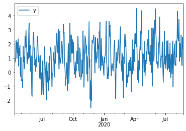

```python
df_ar.plot.line(y = 'y')
```

## Statistique

```python
import seaborn as sns

cm = sns.light_palette("green", as_cmap=True)
```

```python
df_ar.assign(month = lambda x:x.index.month,
            year = lambda x:x.index.year).groupby('month').agg({
    'y':['min','max', 'mean']
}).style.background_gradient(cmap=cm)
```

| month | y min | y max | y mean |
| --- | --- | --- | --- |
| 1 | -0.449666 | 3.62647 | 1.09118 |
| 2 | -1.86643 | 3.22744 | 0.90064 |
| 3 | -1.3616 | 2.71746 | 0.657384 |
| 4 | -0.963138 | 4.52106 | 1.37691 |
| 5 | -1.07252 | 3.67874 | 1.30132 |
| 6 | -1.69245 | 4.49454 | 1.10059 |
| 7 | -1.96339 | 2.24554 | 0.453729 |
| 8 | -0.335271 | 4.31941 | 1.55193 |
| 9 | -1.31029 | 3.4587 | 1.17187 |
| 10 | -0.494073 | 2.93317 | 0.804085 |
| 11 | -2.51533 | 3.5956 | 0.930937 |
| 12 | -0.0549578 | 3.54456 | 1.43522 |